[Click here to return to my portfolio page!](https://marjohnsen.github.io/)

# “Advanced validation of insurance premium models”

In traditional statistical learning, the optimal model is often characterized as the model that minimizes some validation metric. That is, `mean squared error`, `mean absolute error`, or similarly. However, such metrics do not account for the underlying economic criterion that emerges from adverse selection when modelling the insurance premium.

Adverse selection refers to a market situation where policyholders and insurers have different information. Imagine that the expected loss diminishes with the policyholders’ age. Suppose the insurer neglects this risk factor when modeling the premium. In that case, elder policyholders are likely to churn if better options exist in the market. Conversely, younger policyholders will likely stay as no better opportunities exist. The insurer will then lose profitable policies while the unprofitable stay, leading to a systematic loss. Accordingly, a fair premium must be set to minimize the vulnerability to adverse selection, i.e., mispricing.

Alternatively, the actuary can benefit from validating the models through metrics that account for adverse selection, yielding a measure with economic properties as well. Hence, I will demonstrate how to use `measures of lift` and `Ordered Lorenz Curves` to validate premium models. For simplicity, the statistics are kept to a minimum, even though there are superior statistical approaches to estimate, e.g., the Gini standard errors.

I assume you are already familiar with insurance rate-making, the Lorenz curve, and the associated Gini index, so I won’t go into the details of these topics. Luckily, multiple sources online can provide you with knowledge on these topics without charge. I also assume you are familiar with the programming language R and the `tidyverse` packages.

[Click to read about the Lorenz Curve on Wikipedia.](https://en.wikipedia.org/wiki/Lorenz_curve)

[Click to read a great book about insurance rate-making](https://www.casact.org/sites/default/files/2021-01/05-Goldburd-Khare-Tevet.pdf)

## The packages

The models will be based on the dataset `dataCar` from the package `insuranceData`.

```r
library(tidyverse)
library(insuranceData)
library(statmod)
library(scales)
library(caret)
data("dataCar")
```

## Examining the data

The dataset `DataCar` contains insurance data related to cars.

```r
str(dataCar)
```

```
## 'data.frame':    67856 obs. of  11 variables:
##  $ veh_value: num  1.06 1.03 3.26 4.14 0.72 2.01 1.6 1.47 0.52 0.38 ...
##  $ exposure : num  0.304 0.649 0.569 0.318 0.649 ...
##  $ clm      : int  0 0 0 0 0 0 0 0 0 0 ...
##  $ numclaims: int  0 0 0 0 0 0 0 0 0 0 ...
##  $ claimcst0: num  0 0 0 0 0 0 0 0 0 0 ...
##  $ veh_body : Factor w/ 13 levels "BUS","CONVT",..: 4 4 13 11 4 5 8 4 4 4 ...
##  $ veh_age  : int  3 2 2 2 4 3 3 2 4 4 ...
##  $ gender   : Factor w/ 2 levels "F","M": 1 1 1 1 1 2 2 2 1 1 ...
##  $ area     : Factor w/ 6 levels "A","B","C","D",..: 3 1 5 4 3 3 1 2 1 2 ...
##  $ agecat   : int  2 4 2 2 2 4 4 6 3 4 ...
##  $ X_OBSTAT_: Factor w/ 1 level "01101    0    0    0": 1 1 1 1 1 1 1 1 1 1 ...
```

## Preprocessing the data

We will only consider small claims, assuming removing the top 10% largest claims is sufficient. No further preprocessing is needed, as the models used in this example are fairly simple.

```r
data <- dataCar %>%
  top_n(n = nrow(dataCar)-sum(dataCar$claimcst0>0) * .1, desc(claimcst0))
```

## Partitioning the data

The data is partitioned randomly into a train and test set. Typically, you would divide the data by year or similarly to see how well the model predicts the future. Unfortunately, there are no timestamps in this data. Regardless, the data is sufficient to prove the point.

```r
set.seed(103)

data$split <-
  sample(x=c(0,1),
         replace=T,
         size=nrow(data),
         prob=c(.7,.3))

train <- data %>% filter(split == 0)
test <- data %>% filter(split == 1)
```

We can see from the density plot that the distributions in each dataset follow a similar pattern.

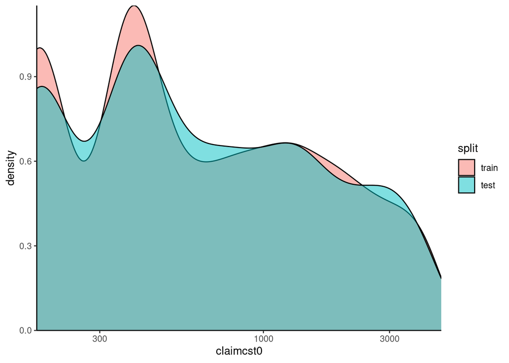

## The models

Two models are computed to demonstrate the validation methods. Both models are based on the frequency-severity decomposition of the pure premium.

### The current model

The first model is assumed to be the `current model` used by an insurance company today.

```r
currentFreqMod <- glm(numclaims~veh_body,
                     family = poisson(link = 'log'),
                     offset = log(exposure),
                     data = train)

currentSevMod <- glm(claimcst0/numclaims~veh_body,
                     family = Gamma(link = 'log'),
                     weights = numclaims,
                     data = train %>% filter(numclaims > 0))
```

### The competing model

The second model is assumed to be a `competing model` that might replace the insurer’s `current model`.

```r
compFreqMod <- glm(numclaims~agecat+veh_age,
                   family = poisson(link = 'log'),
                   offset = log(exposure),
                   data = train)

compSevMod <- glm(claimcst0/numclaims~agecat+veh_value,
                   family = Gamma(link = 'log'),
                   weights = numclaims,
                   data = train %>% filter(numclaims > 0))
```

## Validating the models in terms of RMSE

As you can see, the `current model` has a slightly lower RMSE compared to the `competing model`. However, RMSE does not account for adverse selection. Luckily, Lift might do the trick!

```r
test$currentFreqPred <- predict(currentFreqMod, newdata = test, type = 'response')
test$currentSevPred <- predict(currentSevMod, newdata = test, type = 'response')
test$currentPred <- test$currentFreqPred * test$currentSevPred

test$compFreqPred <- predict(compFreqMod, newdata = test, type = 'response')
test$compSevPred <- predict(compSevMod, newdata = test, type = 'response')
test$compPred <- test$compFreqPred * test$compSevPred

RMSE <- function(true,pred) sqrt(mean((true-pred)^2))

writeLines(
  paste0('RMSE, current model: ',caret::RMSE(test$claimcst0,test$currentPred),
        ' \r\nRMSE, competing model: ',caret::RMSE(test$claimcst0,test$compPred))
)
```

```
## RMSE, current model: 375.77682612923
## RMSE, competing model: 375.809540919966
```

## Measures of lift

I read about lift for the first time in the article [‘Goodness of lift vs. Goodness of fit’](https://www.casact.org/sites/default/files/database/ar_aug2009_1.pdf) in the newsletter “Actuarial Review”. The explanation is short, but simple enough to follow. To quote the authors; *‘the goal of predictive modeling is not to predict the observed loss. The goal is to create accurate estimates of the expected value of losses (which is unobserved)’*.

In an effort to estimate how well a model predicts the unobservable expected value of losses, one can bin the model predictions into, e.g., deciles, and then compute the mean loss and mean premium within each basket. To take it a step further, one can order the predictions based on the relative order between the `current` and `competing` model before binning them. The order ensures that the exact same observations are considered within each group. Conveniently, the optimal model should then minimize the RMSE over the bins.

```r
liftdata <- test %>%
  transmute(
    true = claimcst0,
    currentPred = currentPred,
    compPred = compPred,
    relativePred = compPred/currentPred
  ) %>%
  mutate(deciles = ntile(relativePred,10))

deciledata <- liftdata %>%
  group_by(deciles) %>%
  summarise(mean_true = mean(true),
            mean_currentPred = mean(currentPred),
            mean_compPred = mean(compPred))
```

```r
writeLines(
  paste0('RMSE, current model: ',RMSE(deciledata$mean_true,deciledata$mean_currentPred),
        ' \r\nRMSE, competing model: ',RMSE(deciledata$mean_true,deciledata$mean_compPred))
)
```

```
## RMSE, current model: 9.82249452120118
## RMSE, competing model: 9.72151482813439
```

You can now observe that the `competing model` predicts the mean loss better than the `current model`, implying that the `competing model` is now the optimal model. You can also observe the results in the plot below.

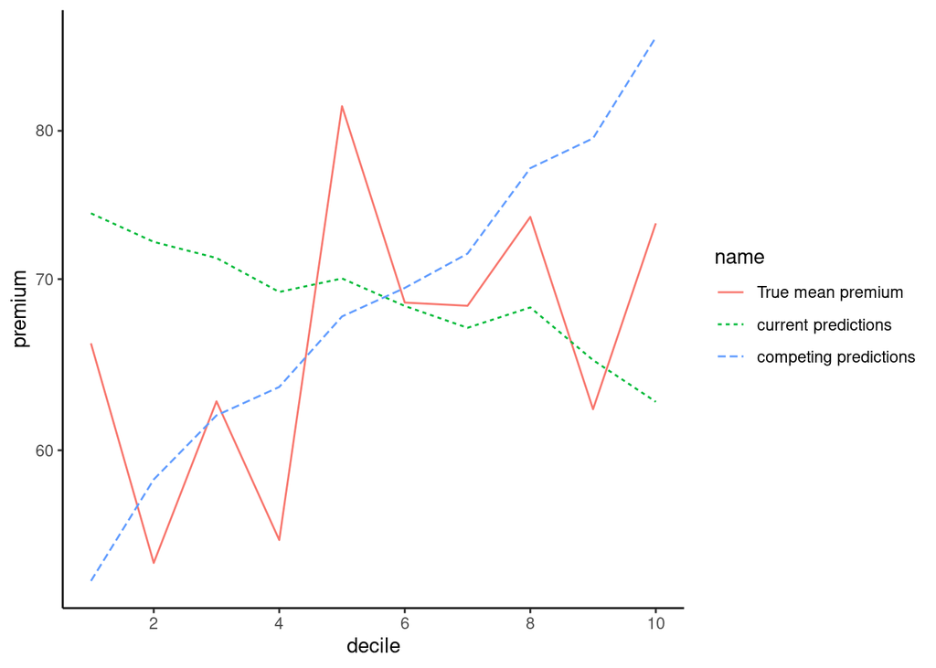

## The economic component from the lift measure

Furthermore, regarding the economic properties implied by adverse selection, we can now compute the estimated gain/loss if the `current model` were to be replaced.

Let’s assume that the `competing model` exists in the market. Then, in line with adverse selection, the policies susceptible to lower premiums from the `competing model` are likely to churn. The rest will remain as no better option exists. Consequently, the possible loss of not adopting the `competing model` can be calculated by subtracting the mean loss from the premium for every policy with a relative premium less than one. The sum of these losses can then be interpreted as the maximal gain by adopting the `competing model`. To further quantify, one can compute the loss as a share of the total premium.

```r
profitloss_current <- liftdata %>%
  left_join(deciledata, by = 'deciles') %>%
  filter(relativePred < 1) %>%
  transmute(profit = currentPred-mean_true) %>%
  pull(profit)

writeLines(paste('The profit lost to the competing model as a share of the current total premium:',sum(profitloss_current)/sum(test$currentPred)))
```

```
## The profit lost to the competing model as a share of the current total premium: 0.0541440061458211
```

You can of course turn it around and check how much profit the ‘current model’ can expose in the ‘competing model’. Keep in mind that we only consider the observations where the `competing model` can offer a better premium. Hence why profit can be exposed in both models. In this case, the profit seems to be larger when using the competing model as the current model? (Maybe these results are not significant?)

```r
profitloss_comp <- liftdata %>%
  left_join(deciledata, by = 'deciles') %>%
  filter(relativePred > 1) %>%
  transmute(profit = compPred-mean_true) %>%
  pull(profit)

writeLines(paste('The profit lost to the current model as a share of the current total premium:',sum(profitloss_comp)/sum(test$compPred)))
```

```
## The profit lost to the current model as a share of the current total premium: 0.0551631395367625
```

## Ordered Lorenz Curves

One of the lift measures’ great benefits is that they are easy to interpret. However, the results highly depend on the number of bins used. Moreover, a few severely mispriced policies can hide inside one of the bins. The application of Ordered Lorenz Curves offers a more refined metric, but at the cost of some more complexity.

Ordered Lorenz Curves are based on the ordinary Lorenz Curve proposed by Lorenz in his research on wealth distributions. The wealth distribution is derived by computing the cumulative proportion of income and comparing it to the cumulative proportion of individuals. The wealth distribution, i.e., the Lorenz Curve, can then be visualized by plotting the income distribution on the y-axis and the population distribution on the x-axis. A convex curve would indicate that the income is unequally distributed, whereas a 45-degree line, known as the line of equality, would indicate a perfectly equal distribution.

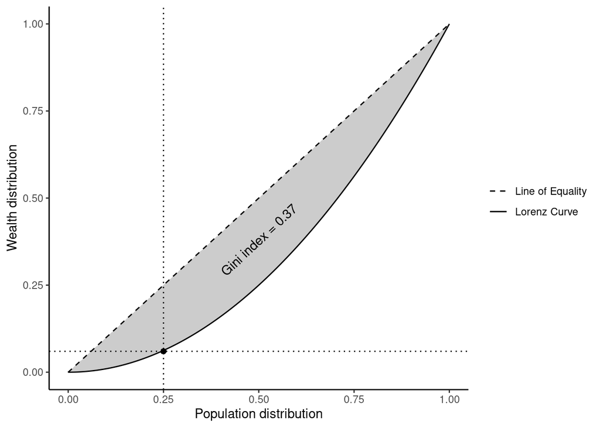

In application to premium model validation, the income and the respective population are replaced by the cumulative proportion of observed losses and premiums. The cumulative proportions are computed based on the order of the same relative premium used when computing the lift. Again, the relative order will ensure that we always compare the same policies across the distribution.

The line of equality now represents a situation where the insurer is in a break-even situation, meaning that the share of premiums covers the share of losses at a certain point. This must not be misunderstood as the models being just as good. For example, both models can be profitable relative to each other. Recall from the lift measures that we only consider the policies where the `competing model` can offer a better premium. By following the same principles, one can see that both models can “take” policies from each other. Accordingly, we intend to find the model that is the most profitable relative to the other.

When the relative premium is below 1 — meaning that the `competing model` is cheaper – the convexity of the line will increase due to the profit exposed. We can then use the area between the Lorenz Curve and the line of equality, i.e., the Gini Index, to determine how much profit the `competing model` is exposing in the `current model`.

In reality, we might have several models to test. To extract the optimal model, we can test every model as the `current model` and compute the Gini Index for all remaining models. The optimal model can then be defined as the `current model` that minimizes the maximum the “competing Gini” computed over the remaining `competing models`. The `current model` that minimizes the Gini over its competitors can be assumed to be the most robust against other competing models in the market. This framework is known as the mini-max strategy.

The Ordered Lorenz Curves are fairly complex and challenging to explain with few words. Keep in mind that this post intends to demonstrate its applications in a simple manner. Hopefully, the application will be self-explanatory. Nevertheless, I will provide you with the related research papers at the end. (All credit to Frees, Edward W. Jed, Glenn Meyers, and A. David Cummings for coming up with this genius application of Lorenz curves and the Gini index).

### Add a third model

To better demonstrate the mini-max strategy, we add a third model. This model simply predicts the mean from the training set, weighted by the exposure from the test set.

```r
test$meanPred <- mean(train$claimcst0/train$exposure) * test$exposure
```

### Computing the Ordered Lorenz Curves

Then, we construct a function that computes the Gini index for a given `current` and `competing model`. This computation method simply computes the empirical Gini directly from the observed data.

```r
gini <-
  function(current,competing,data) {
    data <-
      data %>%
      mutate(
        P = !!sym(current),
        S = !!sym(competing),
        R = S/P
      ) %>%
      arrange(R) %>%
      mutate(
        prem = cumsum(P)/sum(P),
        loss = cumsum(claimcst0)/sum(claimcst0)
      )

    prem <- data$prem
    loss <- data$loss

    gini <- 1 - sum((lead(prem)-prem)*(lead(loss)+loss),na.rm = T)

    return(gini)
  }
```

We then construct a grid to store all possible combinations of current/competing models and the computed Gini indices.

```r
models <- c('currentPred','compPred','meanPred')

gini_grid <-
  expand.grid(models,models) %>%
  as_tibble() %>%
  mutate_all(as.character) %>%
  filter(Var1 != Var2) %>%
  rename(current = Var1,
         competing = Var2)
```

Finally, we map the Gini indices to the grid by applying all combinations of `competing model` vs `current model`.

```r
gini_grid$gini <- map2_dbl(gini_grid$current,gini_grid$competing,gini, data = test)
gini_grid
```

```
## # A tibble: 6 × 3
##   current     competing       gini
##   <chr>       <chr>          <dbl>
## 1 compPred    currentPred  0.0503
## 2 meanPred    currentPred  0.0370
## 3 currentPred compPred     0.0581
## 4 meanPred    compPred     0.0692
## 5 currentPred meanPred    -0.00322
## 6 compPred    meanPred     0.0311
```

We can now find the `current model` that minimizes its maximal competing Gini Index. From the table below, we can observe that the `competing model` minimizes its maximal Gini acting as a current model. Thus, the `competing model` can be assumed to be the optimal model (The column represents the competing, and the rows represents the current).

One of the great properties of the Gini index is that you can estimate the possible profit increase by dividing the `competing Gini` by 2. For example, a `competing Gini` of 0.1 can be translated to a maximal profit gain by 5%. You can then assume that the maximal possible profit gain by adopting the `competing model` equals 5%. According to the Gini indices, the `competing model` can now find the most profit.

One can also observe that none of these models are particularly good, as they do not expose a lot of profitability in the mean model.

```r
minimax <-
  gini_grid %>%
  pivot_wider(names_from = competing, values_from = gini) %>%
  mutate(`Max gini` = pmax(!!!syms(models),na.rm = T)) %>%
  arrange(factor(current,models))

minimax
```

```
## # A tibble: 3 × 5
##   current     currentPred compPred meanPred `Max gini`
##   <chr>             <dbl>    <dbl>    <dbl>      <dbl>
## 1 currentPred     NA        0.0581 -0.00322     0.0581
## 2 compPred         0.0503  NA       0.0311      0.0503
## 3 meanPred         0.0370   0.0692 NA           0.0692
```

### Vizualising the Ordered Lorenz Curve

You can also visualize the competing ordered Lorenz curve by each model acting as the current model following this code:

```r
lorenz_data <-
  function(competing,current) {
      test %>%
        transmute(
          y = claimcst0,
          s = as.numeric(!!sym(competing)),
          p = as.numeric(!!sym(current)),
          R = s/p
        ) %>%
        arrange(R) %>%
        transmute(
          prem = cumsum(p)/sum(p),
          loss = cumsum(y)/sum(y)
        )
  }
```

Adding nested data to the gini_grid

```r
gini_grid$plot_data <- map2(gini_grid$competing,gini_grid$current,lorenz_data)
```

Plotting a facet wrap for each current model. You can see that the mean model are not able to expose any profit in the `curentMod` mod at all.

The larger the area between the line of equality and the Ordered Lorenz Curve, the greater profit is exposed in the `current model`. You can quickly draw a conclusion that these models are not that different, but we will need a statistical test to prove this hypothesis.

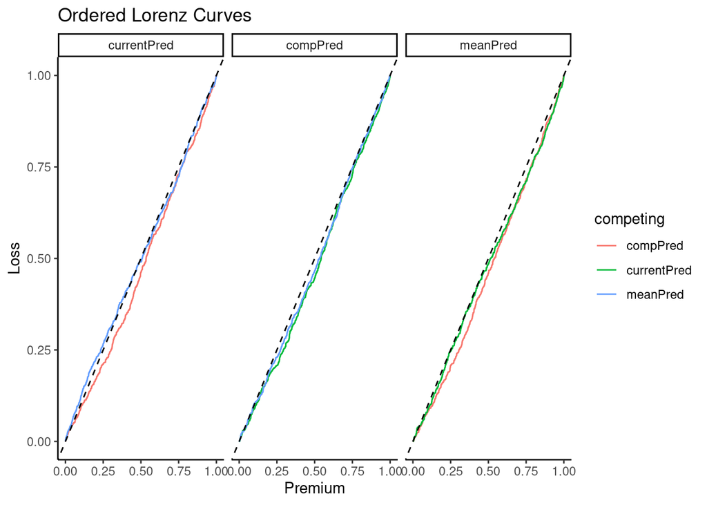

```r
lorenz_curve_plots <-
  gini_grid %>%
    unnest(plot_data) %>%
    mutate(
      current = factor(current,
              levels = models)) %>%
    ggplot(aes(prem,loss, color = competing)) +
    geom_line() +
    geom_abline(slope = 1, linetype = 'dashed') +
    facet_wrap(~current) +
    ylab('Loss') +
    xlab('Premium') +
    labs(title = 'Ordered Lorenz Curves') +
    theme_classic()

lorenz_curve_plots
```

### Statistical test

The mini-max strategy leads to finding the optimal model. Regardless, it does not tell whether the Gini index is statistically different from another.

One alternative is to run a paired one-sided T-test from a bootstrap sample of Gini indices. We can then determine whether the Gini index is statistically larger than its competitors. You can consider the `current model` as the null hypothesis, and the `competing model` as the alternative hypothesis.

We first make a function that extracts bootstrap-samples of the data, and then compute Gini indices using both models as the `competing model`.

```r
gini_sampler <- function(current,competing,data){
  sample = data %>%
    sample_n(nrow(data),
             replace = T)

  gini_s <- gini(current = current,
                 competing = competing,
                 data = sample)

  gini_p <- gini(current = competing,
                 competing = current,
                 data = sample)

  return(list(s = gini_s,
              p = gini_p))
}
```

We then make a function that returns the p-value.

```r
gini_p_values <- function(current,competing,data,n){

  gini_sample <- map_dfr(1:n,
                         ~gini_sampler(current = current,
                                       competing = competing,
                                       data = data))

  pvalue <- t.test(gini_sample$s
                   ,gini_sample$p
                   ,alternative = 'greater'
                   ,paired = T)$p.value

  return(pvalue)
}
```

We can obtain P-values for all combinations of models by iterating over the `gini_grid`.

```r
gini_grid$p_values <- map2_dbl(.x = gini_grid$current,
                               .y = gini_grid$competing,
                               .f = ~gini_p_values(current = .x,
                                                   competing = .y,
                                                   data = test,
                                                   n = 50))

pvalues <-
  gini_grid %>%
  select(-gini,-plot_data) %>%
  pivot_wider(names_from = competing, values_from = p_values) %>%
  arrange(factor(current,models))
```

Based on the p-values, the `current` and `competing` models have a significantly larger Gini Index compared to the mean model. However, we can not reject the `current model` in favor of the `competing model.`

```r
gini_grid[,c('competing','current','gini','p_values')]
```

```
## # A tibble: 6 × 4
##   competing   current         gini     p_values
##   <chr>       <chr>          <dbl>        <dbl>
## 1 currentPred compPred     0.0503  0.993
## 2 currentPred meanPred     0.0370  0.0000000136
## 3 compPred    currentPred  0.0581  0.120
## 4 compPred    meanPred     0.0692  0.00000749
## 5 meanPred    currentPred -0.00322 1.00
## 6 meanPred    compPred     0.0311  1.00
```

Sometimes, you might want to compute the confidence interval as well.

```r
gain_interval <- function(current,competing,data,n){

  CI <- list()

  gini_sample <- map_dfr(1:n,
                         ~gini_sampler(current = current,
                                       competing = competing,
                                       data = data))

  ttest <- t.test(gini_sample$s,
                  alternative = 'two.sided')$conf.int

  output <- list(lower = ttest[1],upper = ttest[2])

  return(output)
}

gain_interval('meanPred','compPred',test,100)
```

```
## $lower
## [1] 0.06931096
##
## $upper
## [1] 0.07762572
```

### How well does the gini change across the different bootstrap samples?

Computing a quick sample:

```r
gini_samples <- map_dfr(1:250,
                        ~gini_sampler(current = models[1],
                                      competing = models[2],
                                      data = test))
```

Highly correlated, but not perfect. Recall that a Gini of .6 does not translate to the a gini of .4 when using the other model as the `competing model`.

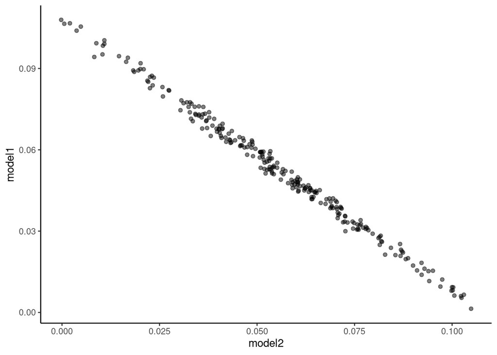

```r
gini_samples %>%
  ggplot(aes(s,p)) +
  geom_point(alpha = .5) +
  theme_classic() +
  ylab('model1') +
  xlab('model2')
```

You can also plot the densities to illustrate Gini distributions.

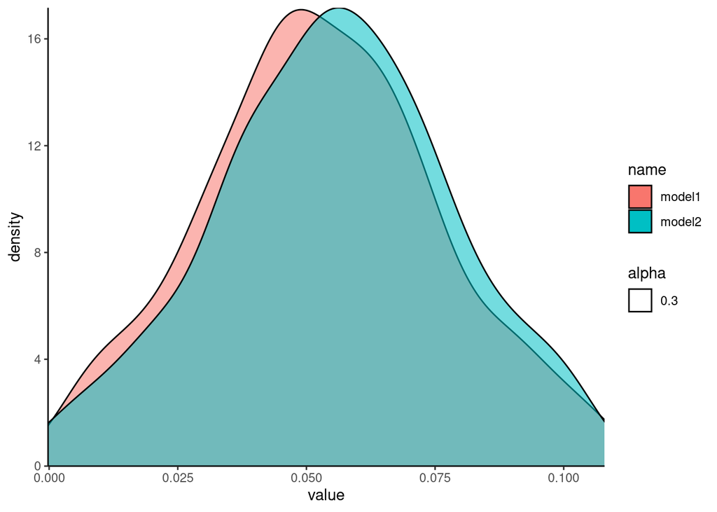

```r
gini_samples %>%
  rename('model2' = 's',
         'model1' = 'p') %>%
  pivot_longer(c(model1,model2)) %>%
  ggplot(aes(value, fill = name,alpha = .3)) +
  geom_density()  +
  scale_x_continuous(expand = c(0, 0)) +
  scale_y_continuous(expand = c(0, 0)) +
  theme_classic()
```

# Wrap up

This article demonstrates how standard metrics can easily fool us into believing we have found the optimal model. By testing 3 different validation methods, we moved from favoring the `current model` to favoring the `competing model`, before favoring no model at all. At this stage, you should keep the `current model` until you can prove that some other model can do a better job. A better job implies that the expected profit of implementing this model should exceed the expected cost of implementation.

[Click here to return to my portfolio page!](https://marjohnsen.github.io/)

# Bibliography

Alston, Carmen M. 2016. “Adverse Selection.” In *Adverse Selection*. Encyclopedia Britannica. https://www.britannica.com/topic/adverse-selection.

Dunn, Peter K., and Gordon K. Smyth. 2018. *Generalized Linear Models with Examples in r*. 1st ed. 2018. Springer Texts in Statistics. New York, NY: Springer New York : Imprint: Springer. https://doi.org/10.1007/978-1-4419-0118-7.

Frees, Edward W. Jed, Glenn Meyers, and A. David Cummings. 2014. “Insurance Ratemaking and a Gini Index: Insurance Ratemaking and a Gini Index.” *Journal of Risk and Insurance* 81 (2): 335–66. https://doi.org/10.1111/j.1539-6975.2012.01507.x.

Frees, Edward W., Glenn Meyers, and A. David Cummings. 2011. “Summarizing Insurance Scores Using a Gini Index.” *Journal of the American Statistical Association* 106 (495): 1085–98. https://doi.org/10.1198/jasa.2011.tm10506.

Hastie, Trevor, Robert Tibshirani, and J. H. Friedman. 2009. *The Elements of Statistical Learning: Data Mining, Inference, and Prediction*. 2nd ed. Springer Series in Statistics. New York, NY: Springer. https://hastie.su.domains/ElemStatLearn/.

Meyers, Glenn. 2008. “The Value of Lift.” *The Actuarial Review* 35 (2): 16–17. https://www.casact.org/sites/default/files/database/ar_may2008_1.pdf.

Meyers, Glenn, and A. David Cummings. 2009. “"Goodness of Fit" Vs. "Goodness of Lift".” *The Actuarial Review* 36 (3): 16–17. https://www.casact.org/sites/default/files/database/ar_aug2009_1.pdf.

Niemerg, Michael. 2019. “All about Them Curves: Ordered Lorenz Curves and Lift Curves.” *Society of Actuaries*, no. 20 (May): 10–13. https://www.soa.org/globalassets/assets/library/newsletters/predictive-analytics-and-futurism/2019/may/2019-predictive-analytics-iss20-niemerg.pdf.